# What makes a book successful?

Genres will be split to as many features as it has levels:

```python
#Splitting to see the distribtution of genres through the various levels:
t= pd.DataFrame()
t[['Genre1','Genre2','Genre3','Genre4','Genre5','Genre6','Genre7','Genre8','Genre9','Genre10']] = df_books['genres'].str.split(',',expand=True)

#Cleaning text
for i in t.columns:
    t[i] = t[i].str.replace(r"\['|'$|'\]$|^ '",'',regex=True)
```

```
############### Univariate analysis - Categorical ###############

This is univariate analysis for ' Genre1 '
                     Count  Percentage
Fiction             13296       42.04
Classics             2270        7.18
Mystery              2033        6.43
Science Fiction      1966        6.22
Fantasy              1568        4.96
Nonfiction           1568        4.96
Historical Fiction   1413        4.47
Romance              1359        4.30
Horror               1240        3.92
Young Adult           661        2.09
Humor                 402        1.27
History               348        1.10
Travel                331        1.05
Chick Lit             310        0.98
Thriller              241        0.76
Short Stories         230        0.73
Childrens             221        0.70
Historical Romance    216        0.68
Poetry                155        0.49
Biography             133        0.42
Science               129        0.41
Memoir                122        0.39
Self Help             100        0.32
Plays                  93        0.29
Picture Books          86        0.27
Comics                 83        0.26
Adventure              78        0.25
True Crime             75        0.24
Christian              69        0.22
Health                 51        0.16
Christian Fiction      47        0.15
Philosophy             39        0.12
Spirituality           37        0.12
Writing                36        0.11
Westerns               35        0.11
Wicca                  32        0.10
```

[output cut: 52 more lines]

```
Paranormal              2        0.01
Christian Living        1        0.00
Urban                   1        0.00
India                   1        0.00
Computer Science        1        0.00
Family                  1        0.00
Bande Dessinée          1        0.00
Books About Books       1        0.00
Design                  1        0.00
Civil War               1        0.00
Martial Arts            1        0.00
Leadership              1        0.00
Race                    1        0.00
Christianity            1        0.00
Gardening               1        0.00
```

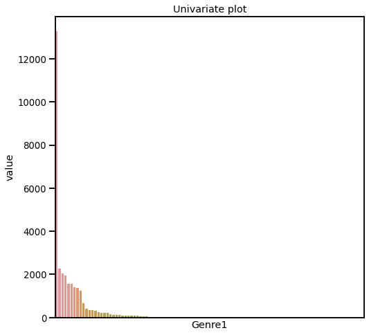

```
This is univariate analysis for ' Genre2 '
                     Count  Percentage
Fiction             10382       32.83
Historical Fiction   2117        6.69
Nonfiction           1711        5.41
Thriller             1698        5.37
Contemporary         1619        5.12
...                   ...         ...
Film                    1        0.00
Occult                  1        0.00
Botswana                1        0.00
Faith                   1        0.00
Presidents              1        0.00

[158 rows x 2 columns]
```

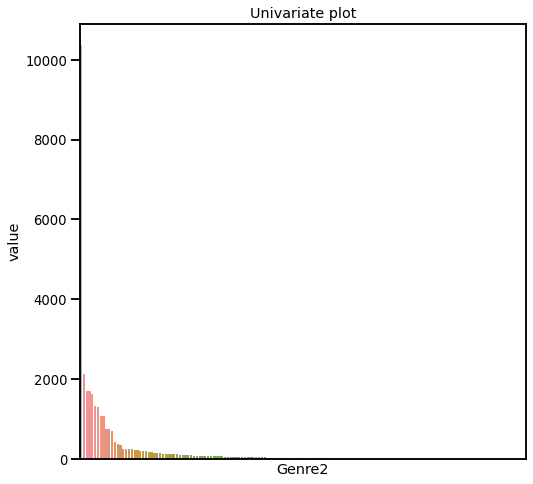

```
This is univariate analysis for ' Genre3 '
                      Count  Percentage
Mystery               2259        7.14
Thriller              2148        6.79
Fiction               2117        6.69
Classics              1850        5.85
Historical Fiction    1699        5.37
...                    ...         ...
Tasmania                 1        0.00
Russia                   1        0.00
New Age                  1        0.00
Canadian Literature      1        0.00
Japan                    1        0.00

[232 rows x 2 columns]
```

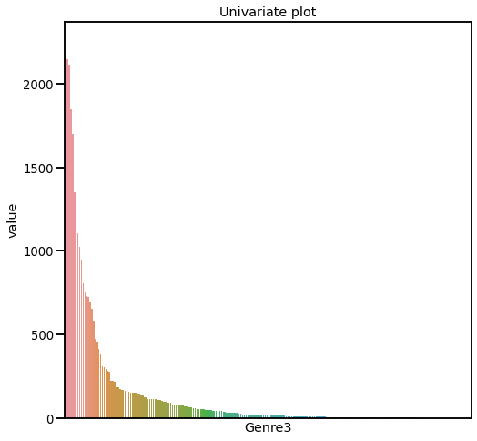

```
This is univariate analysis for ' Genre4 '
                Count  Percentage
Contemporary    1769        5.59
Classics        1374        4.34
Historical      1193        3.77
Crime           1179        3.73
Thriller        1162        3.67
...              ...         ...
Leadership         1        0.00
Romanticism        1        0.00
Urban Studies      1        0.00
Morocco            1        0.00
Dark Fantasy       1        0.00

[269 rows x 2 columns]
```

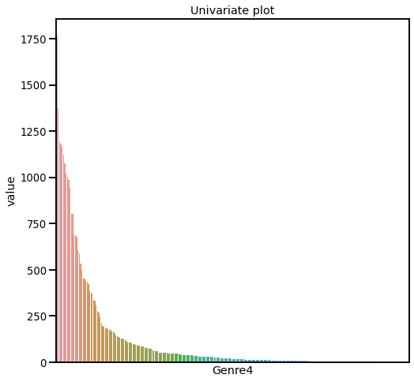

```
This is univariate analysis for ' Genre5 '
                   Count  Percentage
Novels             2012        6.36
Contemporary       1854        5.86
Literature         1554        4.91
Mystery Thriller   1381        4.37
Romance            1230        3.89
...                 ...         ...
Technical             1        0.00
Pirates               1        0.00
Thelema               1        0.00
17th Century          1        0.00
Astronomy             1        0.00

[312 rows x 2 columns]
```

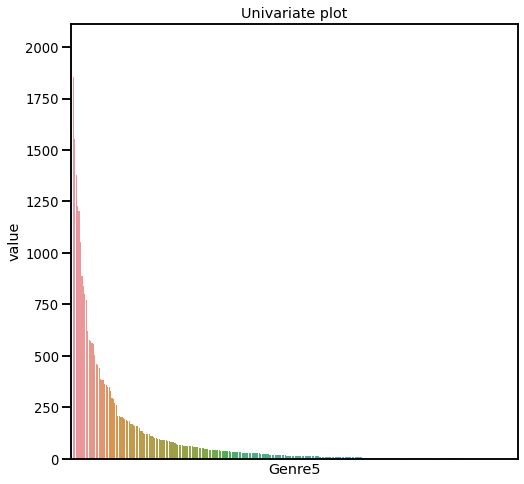

```
This is univariate analysis for ' Genre6 '
                     Count  Percentage
Novels               2749        8.69
Suspense             1384        4.38
Literature           1273        4.03
Adult Fiction        1071        3.39
Literary Fiction     1008        3.19
...                   ...         ...
Culinary                1        0.00
Romanticism             1        0.00
Academic                1        0.00
History Of Science      1        0.00
Historical Fantasy      1        0.00

[330 rows x 2 columns]
```

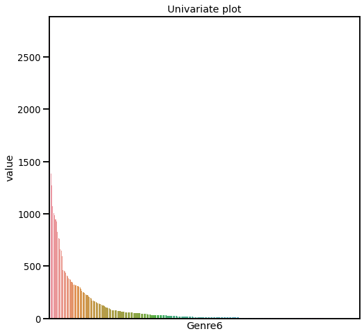

```
This is univariate analysis for ' Genre7 '
                      Count  Percentage
Adult                 2242        7.09
Novels                2223        7.03
Literature            1813        5.73
Adventure             1229        3.89
Adult Fiction         1126        3.56
...                    ...         ...
Counselling              1        0.00
Christian Romance        1        0.00
Computer Science         1        0.00
Prehistory               1        0.00
Japanese Literature      1        0.00

[349 rows x 2 columns]
```

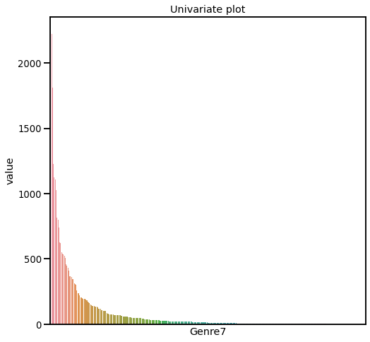

```
This is univariate analysis for ' Genre8 '
                    Count  Percentage
Novels              2630        8.32
Adult               2136        6.75
Literature          1457        4.61
Audiobook           1165        3.68
Classics            1109        3.51
...                  ...         ...
Swashbuckling          1        0.00
Software               1        0.00
Israel                 1        0.00
Political Science      1        0.00
21st Century           1        0.00

[361 rows x 2 columns]
```

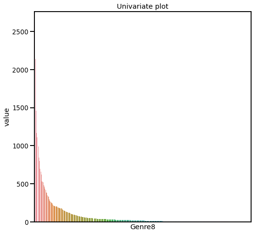

```
This is univariate analysis for ' Genre9 '
                Count  Percentage
Novels          2460        7.78
Drama           1553        4.91
Adult           1414        4.47
Adult Fiction   1101        3.48
Literature       985        3.11
...              ...         ...
Web                1        0.00
Anti Racist        1        0.00
Technical          1        0.00
Holiday            1        0.00
Technology         1        0.00

[370 rows x 2 columns]
```

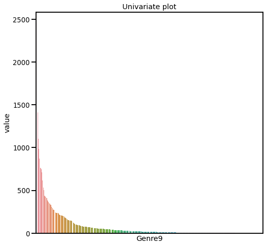

```
This is univariate analysis for ' Genre10 '
                        Count  Percentage
Novels                  2295        7.26
Adult                   2200        6.96
Adult Fiction           2043        6.46
Audiobook               1291        4.08
Contemporary             923        2.92
...                      ...         ...
Discipleship               1        0.00
Literary Criticism         1        0.00
Food                       1        0.00
Language                   1        0.00
Fractured Fairy Tales      1        0.00

[370 rows x 2 columns]
```

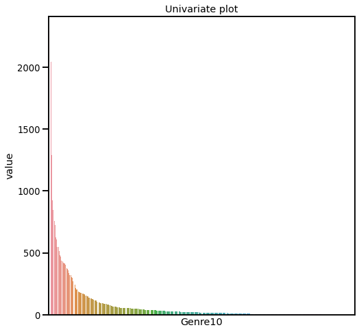

```python
uni_categorical(t[['Genre1','Genre2','Genre3','Genre4','Genre5','Genre6','Genre7','Genre8','Genre9','Genre10']] ,'S')
```

We can see that the distributions of genre are skewed as before splitting and doesn't seem to have any kind of hierarchy in the classification.

The genres will be used to create 2 new features:

```
 - First level genre:
     - Fiction or Non-Fiction
 - Second level(Once classified with one of the following genres, the following will not be evaluated):
     - Classics
     - Historical
     - Thriller
     - Biography
     - Contemporary
     - Fantasy
     - Others
```

and then dropped.

```python
# df_books['genres'].str.contains(r'Fiction')
df_books.loc[df_books['genres'].str.contains(r'Fiction'),'genres-Class1'] = 'Fiction'
df_books['genres-Class1'] = df_books['genres-Class1'].fillna('NonFiction')
```

```python
df_books.loc[df_books['genres'].str.contains(r'Classics'),'genres-Aux1'] = 'Classics'
df_books.loc[df_books['genres'].str.contains(r'Historical|History'),'genres-Aux2'] = 'Historical'
df_books.loc[df_books['genres'].str.contains(r'Thriller'),'genres-Aux3'] = 'Thriller'
df_books.loc[df_books['genres'].str.contains(r'Biography'),'genres-Aux4'] = 'Biography'
df_books.loc[df_books['genres'].str.contains(r'Contemporary'),'genres-Aux5'] = 'Contemporary'
df_books.loc[df_books['genres'].str.contains(r'Fantasy'),'genres-Aux6'] = 'Fantasy'

df_books['genres-Class2'] = pd.Series()

df_books['genres-Class2']= df_books['genres-Class2'].combine_first(df_books['genres-Aux1'])
df_books['genres-Class2']= df_books['genres-Class2'].combine_first(df_books['genres-Aux2'])
df_books['genres-Class2']= df_books['genres-Class2'].combine_first(df_books['genres-Aux3'])
df_books['genres-Class2']= df_books['genres-Class2'].combine_first(df_books['genres-Aux4'])
df_books['genres-Class2']= df_books['genres-Class2'].combine_first(df_books['genres-Aux5'])
df_books['genres-Class2']= df_books['genres-Class2'].combine_first(df_books['genres-Aux6'])

df_books['genres-Class2'] = df_books['genres-Class2'].fillna('Others')
```

```python
df_books.drop(['genres','genres-Aux1','genres-Aux2','genres-Aux3','genres-Aux4','genres-Aux5','genres-Aux6'],axis=1,inplace=True)
```

```
############### Univariate analysis - Categorical ###############

This is univariate analysis for ' genres-Class1 '
             Count  Percentage
Fiction     28114       88.89
NonFiction   3513       11.11
```

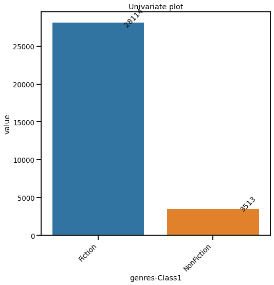

```python
uni_categorical(df_books[['genres-Class1']],'S','Y')
```

We can see that most books have are Fiction as First level genre.

```
############### Univariate analysis - Categorical ###############

This is univariate analysis for ' genres-Class2 '
               Count  Percentage
Classics      10921       34.53
Historical     6013       19.01
Thriller       5557       17.57
Contemporary   4970       15.71
Fantasy        1981        6.26
Biography      1246        3.94
Others          939        2.97
```

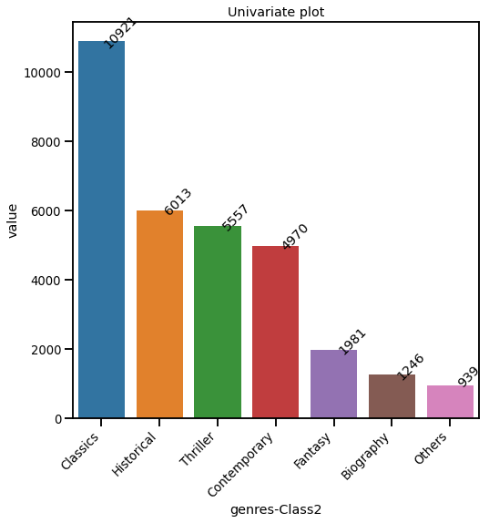

```python
uni_categorical(df_books[['genres-Class2']],'S','Y')
```

### Characters / Setting

We saw that almost 46% of data points is missing. This feature will be dropped as, at this moment there's no manner in which we can identify the characters for other instances

```python
df_books.drop(['characters','setting'],axis=1,inplace=True)
```

### Awards

It'll be renamed to Awards and turned into a boolean feature: it received a award or not?

```python
# https://towardsdatascience.com/feature-engineering-in-python-part-i-the-most-powerful-way-of-dealing-with-data-8e2447e7c69e
#Renaming column
df_books.rename(columns={'awards': 'Awards'},inplace=True)

# Cleaning Transforming feature
df_books['Awards'] = df_books['Awards'].str.replace('[]','',regex=False)

# df_books['Awards'] = np.where(df_books['Awards']!='', 'Y', df_books['Awards'])
# df_books['Awards'].fillna('N',inplace=True)

# Transforming feature
df_books['Awards'] = df_books['Awards'].apply(lambda x: 'N' if x =='' else  'Y' )
# df_books['Awards'].fillna('Y',inplace=True)
```

```
############### Univariate analysis - Categorical ###############

This is univariate analysis for ' Awards '
    Count  Percentage
N  17676       55.89
Y  13951       44.11
```

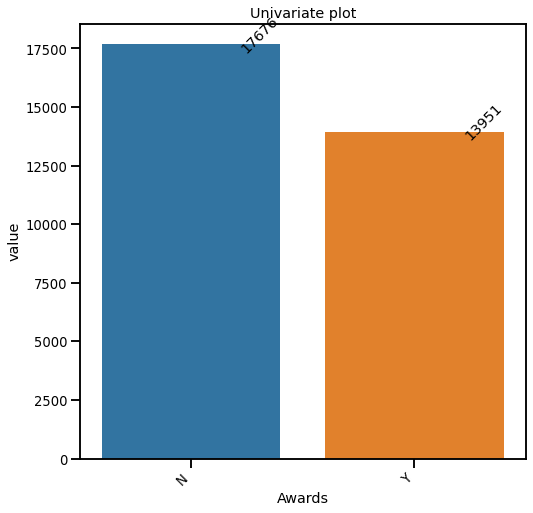

```python
uni_categorical(df_books[['Awards']],'S','Y')
```

We see that a little more than 40% have received an award.

### User ID

It'll be used to feature engineer User-Class:

  After, User-ID will be dropped.

```python
t = df_books.groupby(['User-ID']).size().apply(lambda x: 'Regular reader' if x <= 24 else 'Bookworm')
df_books = df_books.merge(t.to_frame(),left_on='User-ID', right_on='User-ID')
df_books = df_books.rename(columns={0: 'User-Class'})
df_books.drop('User-ID',axis=1,inplace=True)
```

```
############### Univariate analysis - Categorical ###############

This is univariate analysis for ' User-Class '
                 Count  Percentage
Regular reader  28837       91.18
Bookworm         2790        8.82
```

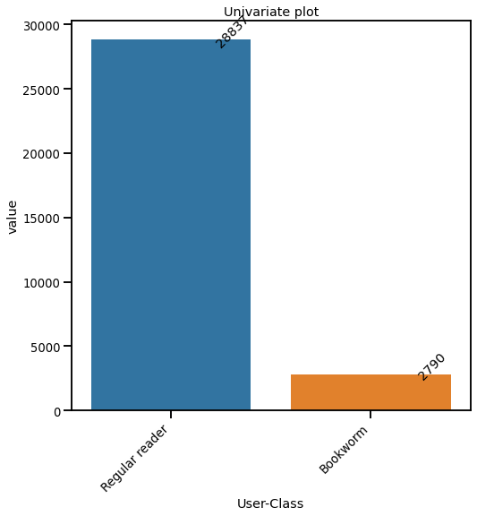

```python
uni_categorical(df_books[['User-Class']],'S','Y')
```

As a first model, this feature will be dropped.

### Location

As observed before Country is the more reliable information. This feature will be split, cleaned and consolidated to Country.

```python
df_books['Location']
```

```
0                slinger, wisconsin, usa
1                              tucson, ,
2                              tucson, ,
3                              tucson, ,
4                              tucson, ,
                      ...
31622      epsom, surrey, united kingdom
31623    birmingham, n/a, united kingdom
31624              conway, arkansas, usa
31625      pittsburgh, pennsylvania, usa
31626        horse branch, kentucky, usa
Name: Location, Length: 31627, dtype: category
Categories (8063, object): ['***********, illinois, usa', ', ,', ', , canada', ', , germany', ..., '¨paris, ile de france, france', 'århus, jylland, denmark', 'él médano, santa cruz de tenerife, canary isl..., 'örebro, n/a, sweden']
```

```python
aux = df_books['Location'].str.split(',',expand=True)

df_books = pd.concat([df_books,aux[2]],axis=1,ignore_index=True)
df_books.rename(columns={0:'ISBN', 1:'Book-Title', 2:'Book-Author',
                   3:'Year-Of-Publication', 4:'Series',
                   5:'firstPublishDate', 6:'Awards', 7:'Book-Rating',
                         8:'Location', 9:'Age', 10:'genres-Class1',
                         11:'genres-Class2',
                   12:'User-Class',13:'User_Country'},inplace=True)
```

```
############### Univariate analysis - Categorical ###############

This is univariate analysis for ' User_Country '
                       Count  Percentage
USA                   23072       72.95
Canada                 3096        9.79
UK                     1161        3.67
Phantasy                955        3.02
Australia               512        1.62
Undefined               472        1.49
Germany                 392        1.24
Spain                   272        0.86
Portugal                257        0.81
Netherlands             187        0.59
Malaysia                185        0.58
New zealand             141        0.45
France                  113        0.36
Singapore                61        0.19
Italy                    61        0.19
Philippines              57        0.18
Austria                  52        0.16
Switzerland              49        0.15
Brazil                   42        0.13
Ireland                  42        0.13
Iran                     38        0.12
Finland                  37        0.12
Belgium                  34        0.11
China                    34        0.11
Sweden                   33        0.10
Japan                    30        0.09
Norway                   28        0.09
Romania                  25        0.08
Poland                   20        0.06
Dominican republic       13        0.04
Mexico                   13        0.04
Denmark                  11        0.03
Aruba                     8        0.03
Israel                    8        0.03
Iceland                   7        0.02
Slovenia                  6        0.02
```

[output cut: 35 more lines]

```
Seoul                     1        0.00
Tonga                     1        0.00
Bulgaria                  1        0.00
Uruguay                   1        0.00
Ecuador                   1        0.00
Tanzania                  1        0.00
Cayman islands            1        0.00
Nigeria                   1        0.00
Monaco                    1        0.00
Ukraine                   1        0.00
Argentina                 1        0.00
Russia                    1        0.00
Cambodia                  1        0.00
Malta                     1        0.00
Albania                   1        0.00
```

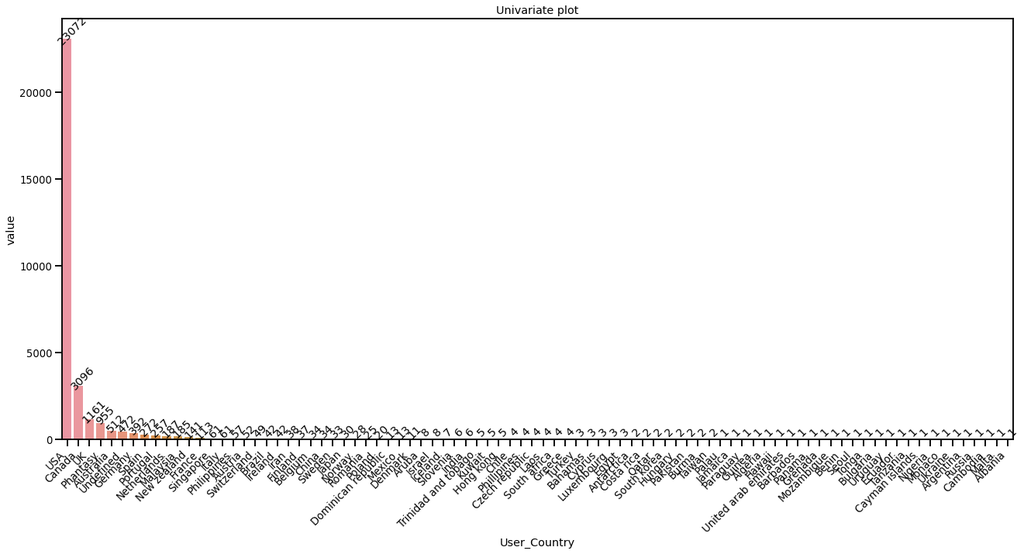

```python
# Standardizing names:
df_books['User_Country'] = df_books['User_Country'].str.replace(r'^.?(new york|virginia|kansas|oklahoma|tennessee|connecticut|united state|maryland|ysa|us|usa|u.s.a.|ca|ca.|louisiana|dc|illinois|north carolina|florida|wisconsin|framingham|massachusetts|united states|idaho|michigan|south dakota|collin|texas|washington|california|ventura county|morgan|new mexico|ohio|usa)$',' usa',regex=True)
df_books['User_Country'] = df_books['User_Country'].str.replace(r'^.?(united kingdom|jersey|cambridgeshire|england|wales|guernsey|north yorkshire|west yorkshire|scotland|united kindgonm|uk)$',' uk',regex=True)
df_books['User_Country'] = df_books['User_Country'].str.replace(r'^.?(la france)$',' france',regex=True)
df_books['User_Country'] = df_books['User_Country'].str.replace(r'^.?(zapopan)$',' mexico',regex=True)
df_books['User_Country'] = df_books['User_Country'].str.replace(r'^.?(shanghai)$',' china',regex=True)
df_books['User_Country'] = df_books['User_Country'].str.replace(r'^.?(euskal herria|andorra|catalonia)$',' spain',regex=True)
df_books['User_Country'] = df_books['User_Country'].str.replace(r'^.?(u.a.e)$','united arab emirates',regex=True)
df_books['User_Country'] = df_books['User_Country'].str.replace(r'^.?(c|n/a - on the road|obviously|far away...|universe|everywhere and anywhere|)$','phantasy',regex=True)
df_books['User_Country'] = df_books['User_Country'].str.replace(r'^.?(n/a)$','undefined',regex=True)
df_books['User_Country'] = df_books['User_Country'].str.replace(r'^.?(okinawa)$',' japan',regex=True)
df_books['User_Country'] = df_books['User_Country'].str.replace(r'^.?(british columbia|ontario|new brunswick)$',' canada',regex=True)
df_books['User_Country'] = df_books['User_Country'].str.replace(r'^.?(co. carlow)$',' ireland',regex=True)
df_books['User_Country'] = df_books['User_Country'].str.replace(r'^.?(queensland)$',' australia',regex=True)
df_books['User_Country'] = df_books['User_Country'].replace('(^\s+|\s+$)', '', regex=True)
df_books['User_Country'] = df_books['User_Country'].replace('(^\s+|\s+$)', '', regex=True)
df_books['User_Country'] = df_books['User_Country'].str.capitalize()
df_books['User_Country'] = df_books['User_Country'].str.replace(r'Usa$','USA',regex=True)
df_books['User_Country'] = df_books['User_Country'].str.replace(r'Uk$','UK',regex=True)

# Plotting
uni_categorical(df_books[['User_Country']],'L','Y')
```

We can see that most of the users lives on USA. We'll further categorize: USA and Other Countries and drop Location.

```
############### Univariate analysis - Categorical ###############

This is univariate analysis for ' User_Country '
                  Count  Percentage
USA              23072       72.95
Other Countries   8555       27.05
```

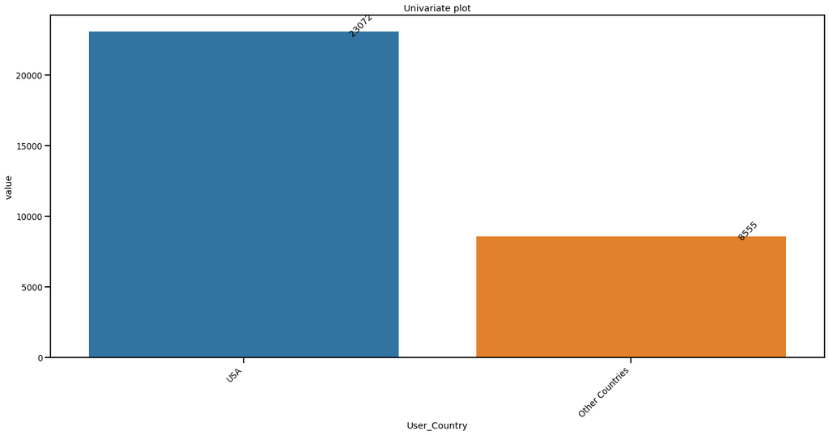

```python
df_books['User_Country'] = df_books['User_Country'].str.replace(r'^.?(Phantasy|Canada|Germany|Australia|Spain|France|Iran|UK|Netherlands|Austria|Undefined|Switzerland|Portugal|New zealand|Malaysia|Ireland|Italy|Mexico|Israel|Brazil|Belgium|Romania|Dominican republic|China|Singapore|Finland|Chile|Sweden|India|Luxembourg|Papua new guinea|Philippines|Cape verde|Poland|Panama|Denmark|Norway|Bahamas|Hong kong|Aruba|Cambodia|Haiti|Burma|Phillipines|Monaco|Russia|South korea|Czech republic|Japan|Egypt|Kuwait|Costa rica|Qatar|Bulgaria|Taiwan|Tanzania|Laos|Sri lanka|United arab emirates|Greece|Cayman islands|Cyprus|Vietnam|Saint lucia|Turkey|Slovenia|South africa|Bolivia|Ukraine|Hungary|Seoul|Malta|Albania|Argentina|Iceland|Solomon islands|Trinidad and tobago|Tonga|Antarctica|Bermuda|Grenada|Uruguay|Madagascar|Hawaii|Canary islands|Benin|Jamaica|Algeria|Barbados|Pakistan|Palau|Paraguay|Cuba|Nigeria|Guinea|Mozambique|Ecuador)$','Other Countries',regex=True)
#Plotting
df_books.drop('Location',axis=1,inplace=True)
uni_categorical(df_books[['User_Country']],'L','Y')
```

We can see that most users are located in the USA.

### Age

As we saw before there are some outliers values:

```
- Below 5 years old
- Greater than 122 years old
```

These values will be dropped as well any missing values. Furthermore, age will be turned into category:

[output not shown]

Age will be dropped after.

Reference: https://www.guinnessworldrecords.com/news/2020/10/the-worlds-oldest-people-and-their-secrets-to-a-long-life-632895

```python
df_books.dropna(inplace=True)

df_books.loc[(df_books['Age'] < 5),'Age'] = np.nan
df_books.loc[(df_books['Age'] > 122),'Age'] = np.nan
df_books.dropna(inplace=True)
```

```
############### Univariate analysis - Numerical ###############

This is univariate analysis for ' Age '
 count                        21195.0
mean                       36.320878
std                        12.570253
min                              5.0
25%                             27.0
50%                             34.0
75%                             44.0
max                            116.0
variance                  158.011263
IQR                             17.0
range                          111.0
skewness                    0.856359
kurtosis                    1.578607
mode        0    33.0
dtype: float64
Name: Age, dtype: object
```

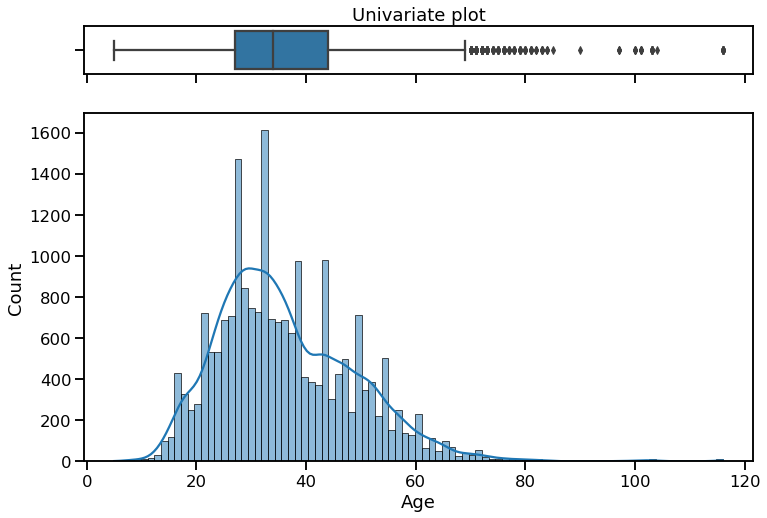

```
Kolmogorov's Statistics=1.000, p=0.000
Normality's test result: Sample does not look Gaussian (reject H0)
```

```python
uni_numerical(df_books[['Age']])
```

```
############### Univariate analysis - Categorical ###############

This is univariate analysis for ' Age_Class '
                   Count  Percentage
Young Adult       12517       59.06
Adult/Senior       7375       34.80
Child / Teenager   1303        6.15
```

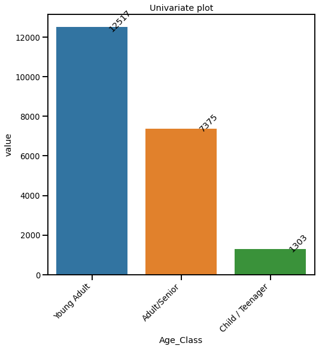

```python
# Based Source:  https://integrisok.com/resources/on-your-health/2015/october/stages-of-life-health-for-every-age

df_books['Age_Class'] = np.where(df_books['Age'] <= 19 , 'Child / Teenager',
                                 np.where(df_books['Age'] <= 39 , 'Young Adult', 'Adult/Senior'))
uni_categorical(df_books[['Age_Class']],'S','Y')
df_books.drop('Age',axis=1,inplace=True)
```

We can see that most users are young adults.

### Book ratings

Books ratings will be further categorized to

```
- Successful(>=8)
- Regular
```

```
############### Univariate analysis - Categorical ###############

This is univariate analysis for ' Book-Rating '
     Count  Percentage
8    5477       25.84
10   4350       20.52
9    3940       18.59
7    3535       16.68
5    1635        7.71
6    1503        7.09
4     362        1.71
3     235        1.11
2      99        0.47
1      59        0.28
```

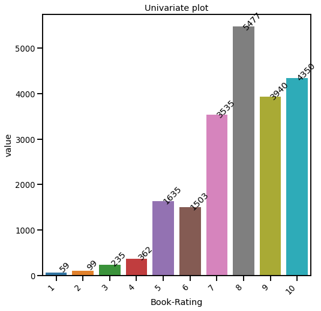

```python
uni_categorical(df_books[['Book-Rating']],'S','Y')
```

```python
# new categories
df_books['Book-Rating'] = df_books['Book-Rating'].astype('int64')

df_books['Book-Rating'] = np.where(df_books['Book-Rating']< 8,
                                        'Regular'
                                        ,'Successful')
df_books['Book-Rating'] = df_books['Book-Rating'].astype('category')
```

```
############### Univariate analysis - Categorical ###############

This is univariate analysis for ' Book-Rating '
             Count  Percentage
Successful  13767       64.95
Regular      7428       35.05
```

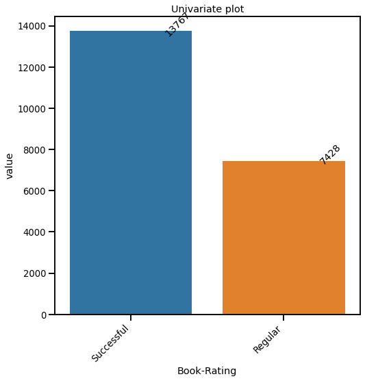

```python
uni_categorical(df_books[['Book-Rating']],'S','Y')
```

Dropping unnecessary columns and rename remaining ones:

```python
df_books.drop(['ISBN','Book-Author','Book-Title','User-Class'],axis=1,inplace=True)
df_books.rename(columns={'Age_Class': 'Group Age',
                         'Awards': 'Awards?',
                         'User_Country': 'User Country',
                         'Year-Of-Publication': 'Year Of Publication',
                         'firstPublishDate': '1st Publication Era',
                         'genres-Class1': 'Genre1',
                         'genres-Class2': 'Genre2',
                         'Series': 'Series?',
                         'Book-Rating': 'Successful?'
                        },inplace=True)
```

Checking for missing values:

```python
chck_miss(df_books)
```

```
Are there any missing value?
                     Total  # Missing  % Missing
1st Publication Era  21195          0        0.0
Awards?              21195          0        0.0
Genre1               21195          0        0.0
Genre2               21195          0        0.0
Group Age            21195          0        0.0
Series?              21195          0        0.0
Successful?          21195          0        0.0
User Country         21195          0        0.0
Year Of Publication  21195          0        0.0
```

## Univariate Analysis

```
############### Univariate analysis - Categorical ###############

This is univariate analysis for ' Successful? '
             Count  Percentage
Successful  13767       64.95
Regular      7428       35.05
```

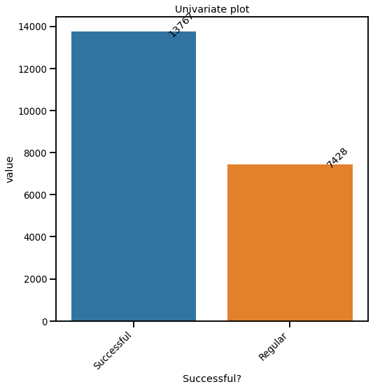

```python
uni_categorical(df_books[['Successful?']],'S','Y')
```

```
############### Univariate analysis - Categorical ###############

This is univariate analysis for ' Awards? '
    Count  Percentage
N  11799       55.67
Y   9396       44.33
```

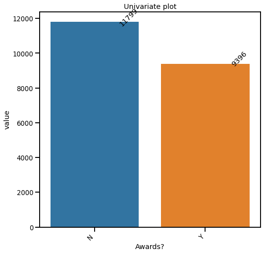

```python
uni_categorical(df_books[['Awards?']],'S','Y')
```

```
############### Univariate analysis - Categorical ###############

This is univariate analysis for ' Genre1 '
             Count  Percentage
Fiction     18870       89.03
NonFiction   2325       10.97
```

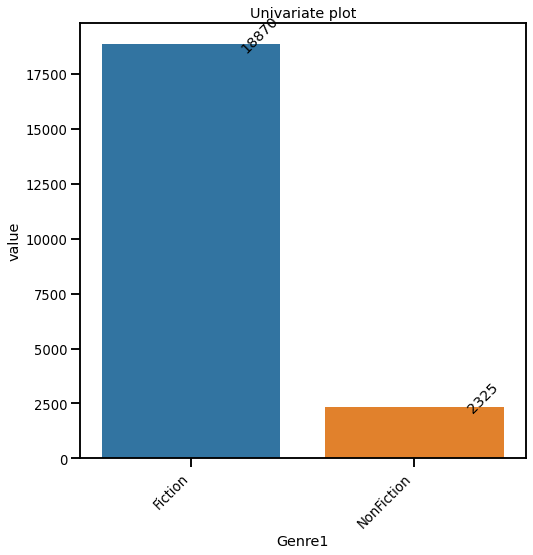

```python
uni_categorical(df_books[['Genre1']],'S','Y')
```

```
############### Univariate analysis - Categorical ###############

This is univariate analysis for ' Genre2 '
               Count  Percentage
Classics       7537       35.56
Historical     3980       18.78
Thriller       3592       16.95
Contemporary   3169       14.95
Fantasy        1439        6.79
Biography       823        3.88
Others          655        3.09
```

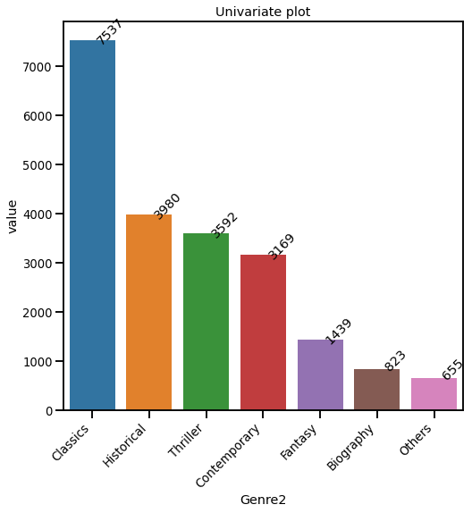

```python
uni_categorical(df_books[['Genre2']],'S','Y')
```

```
############### Univariate analysis - Categorical ###############

This is univariate analysis for ' Group Age '
                   Count  Percentage
Young Adult       12517       59.06
Adult/Senior       7375       34.80
Child / Teenager   1303        6.15
```

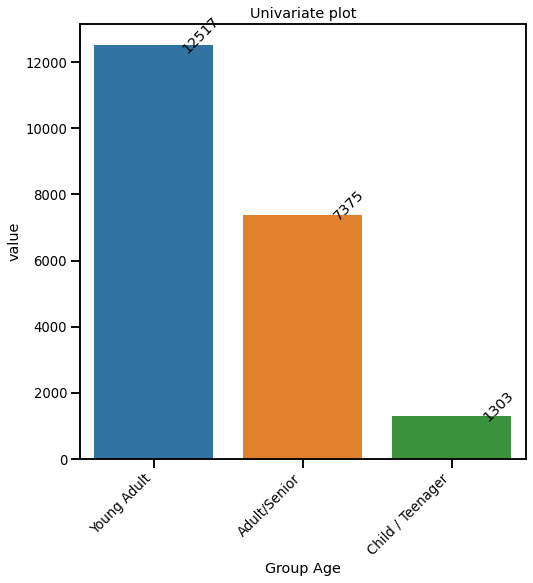

```python
uni_categorical(df_books[['Group Age']],'S','Y')
```

```
############### Univariate analysis - Categorical ###############

This is univariate analysis for ' Series? '
    Count  Percentage
N  13627       64.29
Y   7568       35.71
```

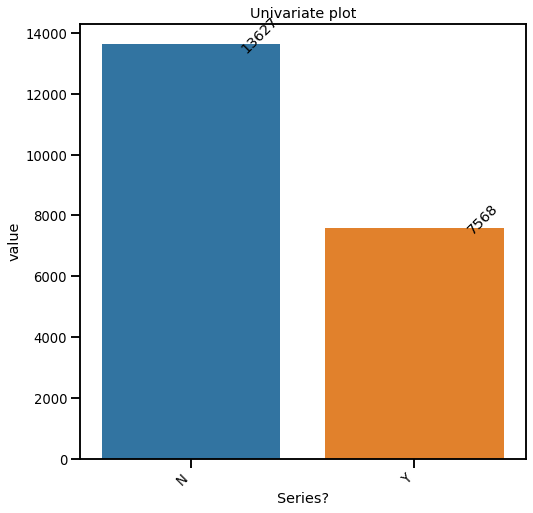

```python
uni_categorical(df_books[['Series?']],'S','Y')
```

```
############### Univariate analysis - Categorical ###############

This is univariate analysis for ' User Country '
                  Count  Percentage
USA              15536        73.3
Other Countries   5659        26.7
```

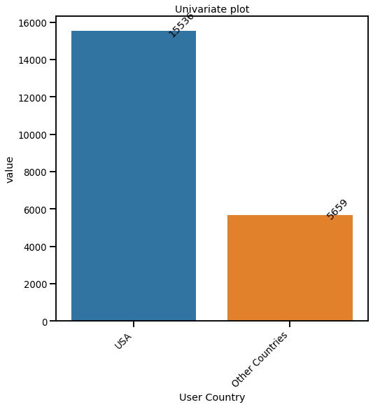

```python
uni_categorical(df_books[['User Country']],'S','Y')
```

```
############### Univariate analysis - Categorical ###############

This is univariate analysis for ' 1st Publication Era '
                               Count  Percentage
Millenium Era (1981 to 1996)   7731       36.48
Boomers and Earlier (<1981)    6503       30.68
Gen Z and after (> 1997)       6052       28.55
Unknown                         909        4.29
```

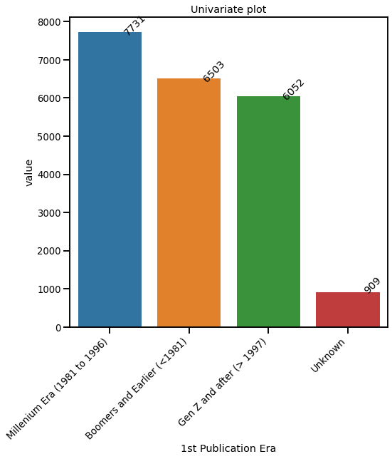

```python
uni_categorical(df_books[['1st Publication Era']],'S','Y')
```

```
############### Univariate analysis - Categorical ###############

This is univariate analysis for ' Year Of Publication '
              Count  Percentage
Before 1985   2042        9.63
2002          1631        7.70
1999          1624        7.66
2000          1621        7.65
2001          1394        6.58
1996          1240        5.85
1995          1230        5.80
1998          1179        5.56
1997          1104        5.21
2003          1079        5.09
1991           991        4.68
1993           917        4.33
1994           857        4.04
1990           815        3.85
1992           800        3.77
1989           706        3.33
1988           661        3.12
1987           383        1.81
2004           378        1.78
1985           295        1.39
1986           248        1.17
```

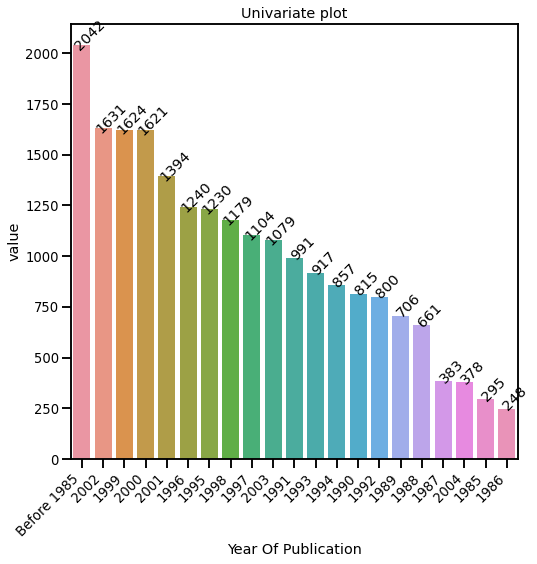

```python
uni_categorical(df_books[['Year Of Publication']],'S','Y')
```

## Bivariate Analysis

```
This is contingency table for:

 Successful?  Regular  Successful
Awards?
N               4314        7485
Y               3114        6282
```

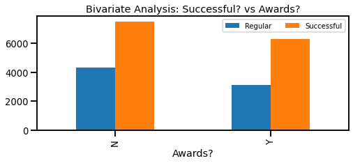

```
Chi-square's Null hypothesis: There's no correlation between variables.

Chi-square's results:
DOF:  1
p-value=  2.3321577048500326e-07

Reject Null Hypothesis. There's some correlation between variables at 5% significance level.
```

```python
bi_categorical_cat(df_books['Awards?'],df_books['Successful?'],'S')
```

```
This is contingency table for:

 Successful?  Regular  Successful
Genre1
Fiction         6753       12117
NonFiction       675        1650
```

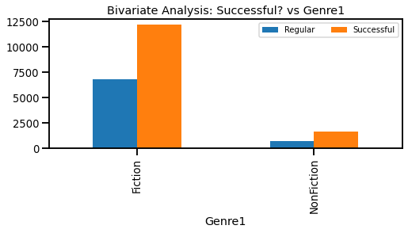

```
Chi-square's Null hypothesis: There's no correlation between variables.

Chi-square's results:
DOF:  1
p-value=  1.3795040632453647e-10

Reject Null Hypothesis. There's some correlation between variables at 5% significance level.
```

```python
bi_categorical_cat(df_books['Genre1'],df_books['Successful?'],'S')
```

```
This is contingency table for:

 Successful?   Regular  Successful
Genre2
Biography         260         563
Classics         2241        5296
Contemporary     1314        1855
Fantasy           473         966
Historical       1427        2553
Others            218         437
Thriller         1495        2097
```

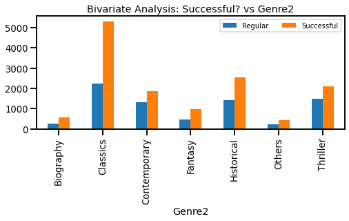

```
Chi-square's Null hypothesis: There's no correlation between variables.

Chi-square's results:
DOF:  6
p-value=  1.7301604858867718e-46

Reject Null Hypothesis. There's some correlation between variables at 5% significance level.
```

```python
bi_categorical_cat(df_books['Genre2'],df_books['Successful?'],'S')
```

```
This is contingency table for:

 Successful?       Regular  Successful
Group Age
Adult/Senior         2498        4877
Child / Teenager      437         866
Young Adult          4493        8024
```

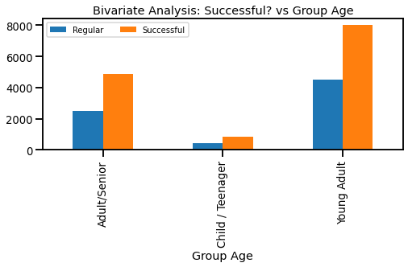

```
Chi-square's Null hypothesis: There's no correlation between variables.

Chi-square's results:
DOF:  2
p-value=  0.007679685804341186

Reject Null Hypothesis. There's some correlation between variables at 5% significance level.
```

```python
bi_categorical_cat(df_books['Group Age'],df_books['Successful?'],'S')
```

```
This is contingency table for:

 Successful?  Regular  Successful
Series?
N               4921        8706
Y               2507        5061
```

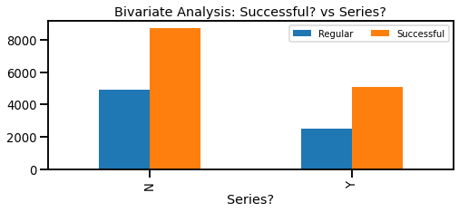

```
Chi-square's Null hypothesis: There's no correlation between variables.

Chi-square's results:
DOF:  1
p-value=  1.3596777796943602e-05

Reject Null Hypothesis. There's some correlation between variables at 5% significance level.
```

```python
bi_categorical_cat(df_books['Series?'],df_books['Successful?'],'S')
```

```
This is contingency table for:

 Successful?      Regular  Successful
User Country
Other Countries     2135        3524
USA                 5293       10243
```

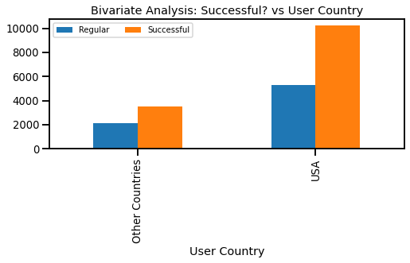

```
Chi-square's Null hypothesis: There's no correlation between variables.

Chi-square's results:
DOF:  1
p-value=  8.566618839513316e-07

Reject Null Hypothesis. There's some correlation between variables at 5% significance level.
```

```python
bi_categorical_cat(df_books['User Country'],df_books['Successful?'],'S')
```

```
This is contingency table for:

 Successful?                   Regular  Successful
1st Publication Era
Unknown                           341         568
Boomers and Earlier (<1981)      2011        4492
Millenium Era (1981 to 1996)     2720        5011
Gen Z and after (> 1997)         2356        3696
```

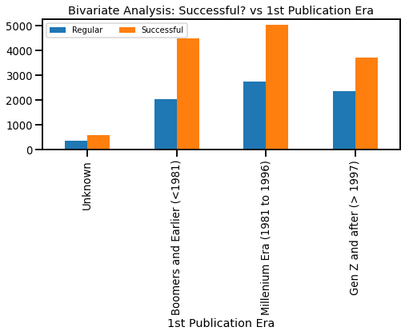

```
Chi-square's Null hypothesis: There's no correlation between variables.

Chi-square's results:
DOF:  3
p-value=  1.2582824060503579e-19

Reject Null Hypothesis. There's some correlation between variables at 5% significance level.
```

```python
bi_categorical_cat(df_books['1st Publication Era'],df_books['Successful?'],'S')
```

```
This is contingency table for:

 Successful?          Regular  Successful
Year Of Publication
Before 1985              604        1438
1985                      96         199
1986                      74         174
1987                     127         256
1988                     197         464
1989                     197         509
1990                     236         579
1991                     374         617
1992                     287         513
1993                     295         622
1994                     317         540
1995                     442         788
1996                     466         774
1997                     405         699
1998                     434         745
1999                     610        1014
2000                     647         974
2001                     518         876
2002                     597        1034
2003                     394         685
2004                     111         267
```

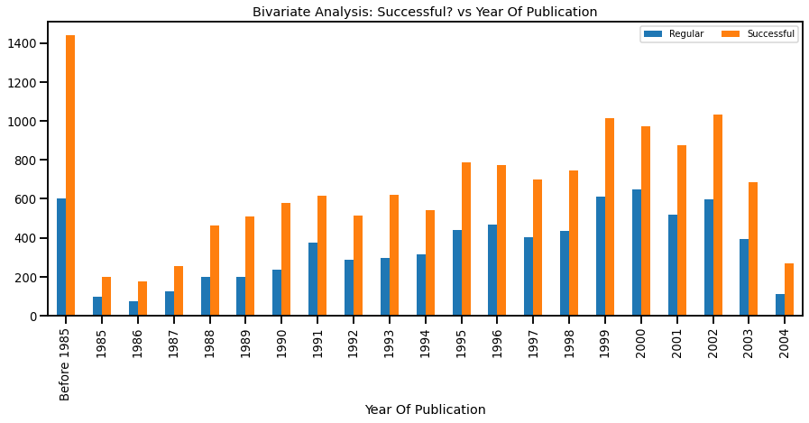

```
Chi-square's Null hypothesis: There's no correlation between variables.

Chi-square's results:
DOF:  20
p-value=  1.9375639692404993e-15

Reject Null Hypothesis. There's some correlation between variables at 5% significance level.
```

```python
bi_categorical_cat(df_books['Year Of Publication'],df_books['Successful?'],'L')
```

# Model

## Creating dummy dataset

```python
df_books.shape
```

```
(21195, 9)
```

```python
target='Successful?'

# Creating copy of df for training:
df_dummy = df_books.copy()

#Dummy variable encoding for categorical features:
cols = ['Year Of Publication', 'Series?', '1st Publication Era', 'Awards?',
        'Genre1','Genre2', 'User Country', 'Group Age']

df_dummy = pd.get_dummies(df_dummy,columns=cols,drop_first=True).reset_index(drop = True)

X = df_dummy.drop([target],axis=1)
y = df_dummy[target]
```

```python
X.head()
```

|  | Year Of Publication_1985 | Year Of Publication_1986 | Year Of Publication_1987 | Year Of Publication_1988 | Year Of Publication_1989 | Year Of Publication_1990 | Year Of Publication_1991 | Year Of Publication_1992 | Year Of Publication_1993 | Year Of Publication_1994 | ... | Genre1_NonFiction | Genre2_Classics | Genre2_Contemporary | Genre2_Fantasy | Genre2_Historical | Genre2_Others | Genre2_Thriller | User Country_USA | Group Age_Child / Teenager | Group Age_Young Adult |
| --- | --- | --- | --- | --- | --- | --- | --- | --- | --- | --- | --- | --- | --- | --- | --- | --- | --- | --- | --- | --- | --- |
| 0 | 0 | 0 | 0 | 0 | 0 | 0 | 0 | 0 | 0 | 0 | ... | 1 | 0 | 0 | 0 | 0 | 0 | 0 | 1 | 1 | 0 |
| 1 | 0 | 0 | 0 | 0 | 0 | 0 | 0 | 0 | 0 | 0 | ... | 0 | 0 | 0 | 0 | 1 | 0 | 0 | 0 | 0 | 1 |
| 2 | 0 | 0 | 0 | 0 | 0 | 0 | 0 | 0 | 0 | 0 | ... | 0 | 0 | 0 | 0 | 1 | 0 | 0 | 0 | 0 | 1 |
| 3 | 0 | 0 | 0 | 0 | 0 | 0 | 0 | 0 | 1 | 0 | ... | 0 | 1 | 0 | 0 | 0 | 0 | 0 | 0 | 0 | 1 |
| 4 | 0 | 0 | 0 | 0 | 0 | 0 | 0 | 0 | 0 | 0 | ... | 0 | 0 | 0 | 0 | 0 | 0 | 1 | 0 | 0 | 1 |

5 rows × 35 columns

```python
y.head()
```

```
0    Successful
1       Regular
2       Regular
3    Successful
4       Regular
Name: Successful?, dtype: category
Categories (2, object): ['Regular', 'Successful']
```

## Checking multicollinearity

```
############### Bivariate analysis - Numerical x Numerical ###############

Correlation (how strong the correlation is):
 Null hypothesis: there’s no association between variables.
 	1.Normal distribution for both variables for pearson;
  	2.homoscedasticity assumes that data is equally distributed about the regression line.
 	3.Linear?
 		Linear: pearson
 		Monotonically related (not normal): spearman kendall hoeffding
```

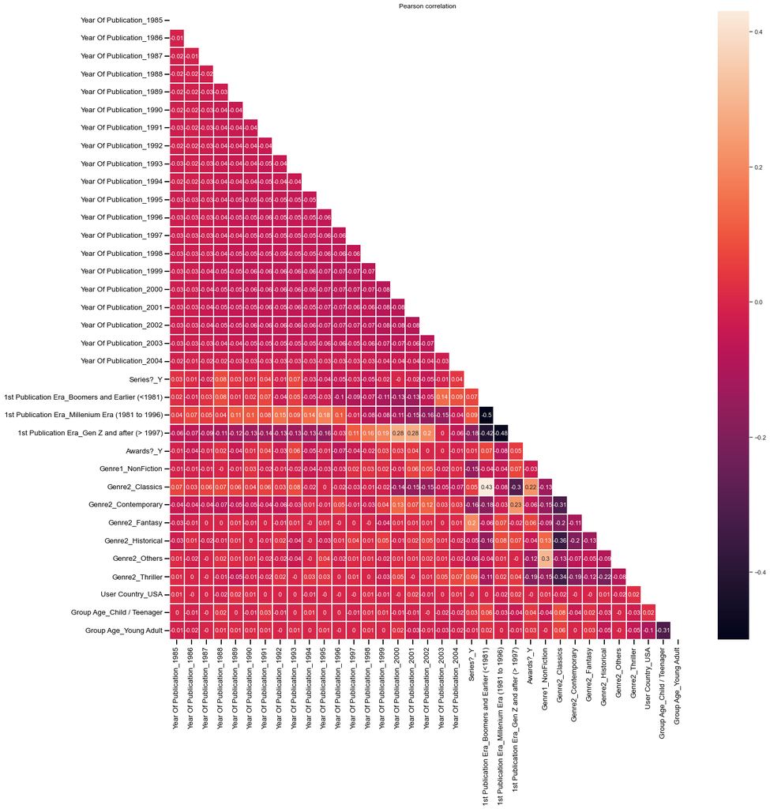

```python
bi_numerical_num(df_dummy)
```

We can see that there's no high correlation among variables.

```python
# Dividing into training and test datasets:
X_train, X_test,y_train,y_test = train_test_split(X,y,random_state=6,test_size=0.3)
```

#### Scaling the features using training set:

```python
sc = StandardScaler()
X_train_scaled = pd.DataFrame(sc.fit_transform(X_train),columns=X_train.columns)
X_test_scaled = pd.DataFrame(sc.transform(X_test),columns=X_test.columns)
X_scaled = pd.DataFrame(sc.transform(X),columns=X.columns)
```

## Fitting and validating Logistic Regression :

```python
param_grid = [
        {
            'C' : [1000,2000],
            'tol': [1e-5,1e-6,1e-7],
            'class_weight':['balanced'],
            'solver':['saga'],
            'max_iter':[100000],
            'random_state':[45879]
        }
       ]

clf = GridSearchCV(LogisticRegression(), param_grid, cv=3,
                           scoring='balanced_accuracy')
clf.fit(X_scaled,y)

print("Best parameters set found on development set:")
print(clf.best_params_)
```

```
Best parameters set found on development set:
{'C': 1000, 'class_weight': 'balanced', 'max_iter': 100000, 'random_state': 45879, 'solver': 'saga', 'tol': 1e-05}
```

```
Model parameters - Logistic Regression:  {'C': 1000, 'class_weight': 'balanced', 'max_iter': 100000, 'random_state': 45879, 'solver': 'saga', 'tol': 1e-05}
```

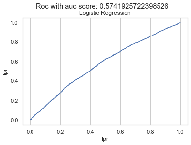

```
Classification report - Logistic Regression
              precision    recall  f1-score   support

     Regular       0.40      0.56      0.46      2197
  Successful       0.70      0.56      0.62      4162

    accuracy                           0.56      6359
   macro avg       0.55      0.56      0.54      6359
weighted avg       0.60      0.56      0.57      6359
```

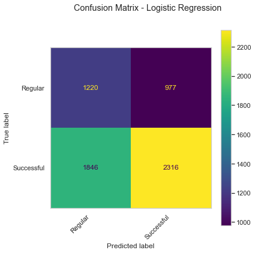

```python
model = LogisticRegression(C= 2000, class_weight='balanced', max_iter=100000, random_state=45879, solver='saga', tol=1e-05)
model.fit(X_train_scaled,y_train)

print('\nModel parameters - Logistic Regression: ',clf.best_params_)

y_test1 = y_test.map({'Regular': 0, 'Successful': 1}).astype(int)
y_pred_prob = model.predict_proba(X_test_scaled)[:,1]
fpr, tpr, thresholds = roc_curve(y_test1, y_pred_prob)

plt.plot(fpr,tpr)
plt.xlabel('fpr')
plt.ylabel('tpr')
plt.title('Logistic Regression')
plt.suptitle('Roc with auc score: {}'.format(roc_auc_score(y_test1,y_pred_prob)))
plt.show()

print('Classification report - Logistic Regression')
y_pred = model.predict(X_test_scaled)
print(classification_report(y_test,y_pred, zero_division=0))

fig, ax = plt.subplots()
fig.set_size_inches(6, 6)
disp = metrics.plot_confusion_matrix(model, X_test_scaled, y_test,ax=ax)
disp.figure_.suptitle("Confusion Matrix - Logistic Regression")
plt.xticks(rotation=45, ha='right')
ax.grid(False)
plt.show()
```

We see that despite having a poor accuracy, precision of succesful is good.

## Fitting and validating KNN:

```python
param_grid = [
        {
            'n_neighbors' : [10,20,30,40,50],
            'weights': ['distance','uniform'],
            'leaf_size':[20,30,50]
        }
       ]

clf = GridSearchCV(neighbors.KNeighborsClassifier(), param_grid, cv=3,
                           scoring='balanced_accuracy')
clf.fit(X,y)

print("Best parameters set found on development set:")
print(clf.best_params_)
```

```
Best parameters set found on development set:
{'leaf_size': 20, 'n_neighbors': 10, 'weights': 'distance'}
```

[output not shown]

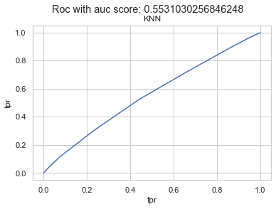

```
Classification report - KNN
              precision    recall  f1-score   support

     Regular       0.39      0.33      0.36      2197
  Successful       0.67      0.73      0.70      4162

    accuracy                           0.59      6359
   macro avg       0.53      0.53      0.53      6359
weighted avg       0.58      0.59      0.58      6359
```

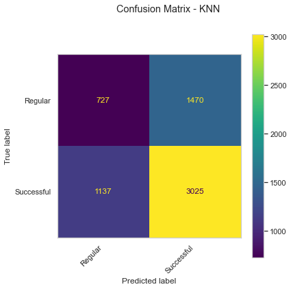

```python
model = neighbors.KNeighborsClassifier(leaf_size=20,n_neighbors=10, weights='uniform')
model.fit(X_train_scaled,y_train)

print('\nModel parameters - KNN: ',clf.best_params_)

y_test1 = y_test.map({'Regular': 0, 'Successful': 1}).astype(int)
y_pred_prob = model.predict_proba(X_test_scaled)[:,1]
fpr, tpr, thresholds = roc_curve(y_test1, y_pred_prob)

plt.plot(fpr,tpr)
plt.xlabel('fpr')
plt.ylabel('tpr')
plt.title('KNN')
plt.suptitle('Roc with auc score: {}'.format(roc_auc_score(y_test1,y_pred_prob)))
plt.show()

print('Classification report - KNN')
y_pred = model.predict(X_test_scaled)
print(classification_report(y_test,y_pred, zero_division=0))

fig, ax = plt.subplots()
fig.set_size_inches(6, 6)
disp = metrics.plot_confusion_matrix(model, X_test_scaled, y_test,ax=ax)
disp.figure_.suptitle("Confusion Matrix - KNN")
plt.xticks(rotation=45, ha='right')
ax.grid(False)
plt.show()
```

We see that although accuracy has increased, precision of successful has diminished.

## Fitting and validating SVM:

```python
param_grid = [
        {
            'loss' : ['log', 'modified_huber'],
            'tol': [1e-3,1e-4,1e-5,1e-6,1e-7],
            'shuffle':[True],
            'fit_intercept': [True,False],
            'random_state': [455547],
            'learning_rate':['constant','optimal','invscaling','adaptive'],
            'eta0':[0.1,0.2],
            'max_iter':[100000]
        }
       ]

clf = GridSearchCV(SGDClassifier(), param_grid, cv=3,
                           scoring='balanced_accuracy')
clf.fit(X_scaled,y)

print("Best parameters set found on development set:")
print(clf.best_params_)
```

```
Best parameters set found on development set:
{'eta0': 0.1, 'fit_intercept': False, 'learning_rate': 'invscaling', 'loss': 'log', 'max_iter': 100000, 'random_state': 455547, 'shuffle': True, 'tol': 1e-05}
```

```
Model parameters - SVM:  {'eta0': 0.1, 'fit_intercept': False, 'learning_rate': 'invscaling', 'loss': 'log', 'max_iter': 100000, 'random_state': 455547, 'shuffle': True, 'tol': 1e-05}
```

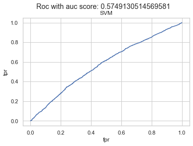

```
Classification report - SVM
              precision    recall  f1-score   support

     Regular       0.40      0.56      0.47      2197
  Successful       0.70      0.55      0.62      4162

    accuracy                           0.55      6359
   macro avg       0.55      0.56      0.54      6359
weighted avg       0.60      0.55      0.57      6359
```

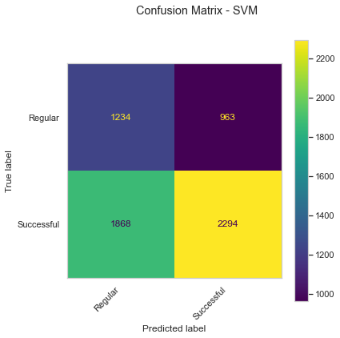

```python
model = SGDClassifier(eta0=0.1, fit_intercept=False, learning_rate='invscaling', loss='log',
                      random_state=455547, shuffle=True, tol=1e-5, max_iter=100000)
model.fit(X_train_scaled,y_train)

print('\nModel parameters - SVM: ',clf.best_params_)

y_test1 = y_test.map({'Regular': 0, 'Successful': 1}).astype(int)
y_pred_prob = model.predict_proba(X_test_scaled)[:,1]
fpr, tpr, thresholds = roc_curve(y_test1, y_pred_prob)

plt.plot(fpr,tpr)
plt.xlabel('fpr')
plt.ylabel('tpr')
plt.title('SVM')
plt.suptitle('Roc with auc score: {}'.format(roc_auc_score(y_test1,y_pred_prob)))
plt.show()

print('Classification report - SVM')
y_pred = model.predict(X_test_scaled)
print(classification_report(y_test,y_pred, zero_division=0))

fig, ax = plt.subplots()
fig.set_size_inches(6, 6)
disp = metrics.plot_confusion_matrix(model, X_test_scaled, y_test,ax=ax)
disp.figure_.suptitle("Confusion Matrix - SVM")
plt.xticks(rotation=45, ha='right')
ax.grid(False)
plt.show()
```

## Fitting and validating AdaBoost:

```python
param_grid = [
        {
            'n_estimators' : [30,40,50,60,70,80,90,100],
            'learning_rate':[0.9,1,1.1,1.2],
            'random_state':[45698],
            'algorithm':['SAMME', 'SAMME.R']
        }
       ]

clf = GridSearchCV(AdaBoostClassifier(), param_grid, cv=3,
                           scoring='balanced_accuracy')
clf.fit(X_scaled,y)

print("Best parameters set found on development set:")
print(clf.best_params_)
```

```
Best parameters set found on development set:
{'algorithm': 'SAMME.R', 'learning_rate': 1, 'n_estimators': 30, 'random_state': 45698}
```

```
Model parameters - AdaBoost:  {'algorithm': 'SAMME.R', 'learning_rate': 1, 'n_estimators': 30, 'random_state': 45698}
```

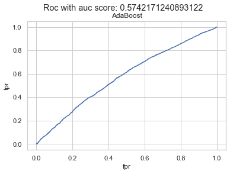

```
Classification report - AdaBoost
              precision    recall  f1-score   support

     Regular       0.47      0.00      0.01      2197
  Successful       0.65      1.00      0.79      4162

    accuracy                           0.65      6359
   macro avg       0.56      0.50      0.40      6359
weighted avg       0.59      0.65      0.52      6359
```

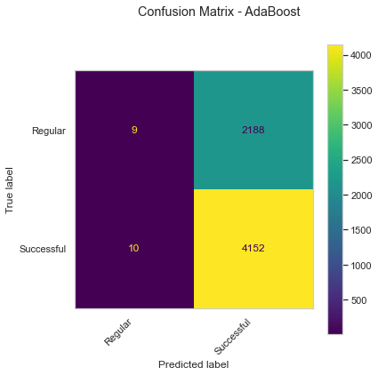

```python
model = AdaBoostClassifier(algorithm='SAMME.R', learning_rate=1, n_estimators=30, random_state=45698)
model.fit(X_train_scaled,y_train)

print('\nModel parameters - AdaBoost: ',clf.best_params_)

y_test1 = y_test.map({'Regular': 0, 'Successful': 1}).astype(int)
y_pred_prob = model.predict_proba(X_test_scaled)[:,1]
fpr, tpr, thresholds = roc_curve(y_test1, y_pred_prob)

plt.plot(fpr,tpr)
plt.xlabel('fpr')
plt.ylabel('tpr')
plt.title('AdaBoost')
plt.suptitle('Roc with auc score: {}'.format(roc_auc_score(y_test1,y_pred_prob)))
plt.show()

print('Classification report - AdaBoost')
y_pred = model.predict(X_test_scaled)
print(classification_report(y_test,y_pred, zero_division=0))

fig, ax = plt.subplots()
fig.set_size_inches(6, 6)
disp = metrics.plot_confusion_matrix(model, X_test_scaled, y_test,ax=ax)
disp.figure_.suptitle("Confusion Matrix - AdaBoost")
plt.xticks(rotation=45, ha='right')
ax.grid(False)
plt.show()
```

We see that accuracy has improved, but precision of succesful has diminished when compared with Logistic regression. FUrthermore, confusion matrix shows an unbalanced classification towards Successful indicating that Regular books have being classified as successful more wrong than previous models.

## Fitting and validating Random Forest:

```python
param_grid = [
        {
            'n_estimators' : [10,20,40,60,80,100,200,300],
            'random_state': [45545],
            'criterion':['gini', 'entropy'],
            'class_weight':['balanced','balanced_subsample'],
            'max_features':['auto', 'sqrt', 'log2']
        }
       ]

clf = GridSearchCV(RandomForestClassifier(), param_grid, cv=3,
                           scoring='balanced_accuracy')
clf.fit(X,y)

print("Best parameters set found on development set:")
print(clf.best_params_)
```

```
Best parameters set found on development set:
{'class_weight': 'balanced_subsample', 'criterion': 'entropy', 'max_features': 'auto', 'n_estimators': 60, 'random_state': 45545}
```

[output not shown]

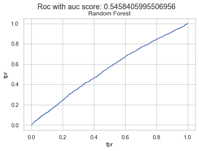

```
Classification report - Random Forest
              precision    recall  f1-score   support

     Regular       0.38      0.47      0.42      2197
  Successful       0.68      0.60      0.64      4162

    accuracy                           0.55      6359
   macro avg       0.53      0.54      0.53      6359
weighted avg       0.58      0.55      0.56      6359
```

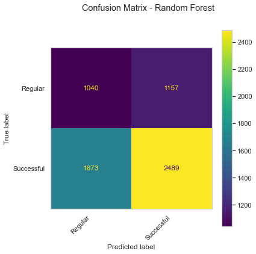

```python
model = RandomForestClassifier(class_weight='balanced_subsample', criterion='entropy', max_features='auto',
                               n_estimators=60, random_state=45545)
model.fit(X_train,y_train)

print('\nModel parameters - Random Forest: ',clf.best_params_)

y_test1 = y_test.map({'Regular': 0, 'Successful': 1}).astype(int)
y_pred_prob = model.predict_proba(X_test)[:,1]
fpr, tpr, thresholds = roc_curve(y_test1, y_pred_prob)

plt.plot(fpr,tpr)
plt.xlabel('fpr')
plt.ylabel('tpr')
plt.title('Random Forest')
plt.suptitle('Roc with auc score: {}'.format(roc_auc_score(y_test1,y_pred_prob)))
plt.show()

print('Classification report - Random Forest')
y_pred = model.predict(X_test)
print(classification_report(y_test,y_pred, zero_division=0))

fig, ax = plt.subplots()
fig.set_size_inches(6, 6)
disp = metrics.plot_confusion_matrix(model, X_test, y_test,ax=ax)
disp.figure_.suptitle("Confusion Matrix - Random Forest")
plt.xticks(rotation=45, ha='right')
ax.grid(False)
plt.show()
```

We see metrics and confusion matrix that approximates Logistic Regression. However, Logistic Regression still provides better classification.

## Fitting and validating Decison Tree:

```python
param_grid = [
        {
            'criterion': ['gini','entropy'],
            'max_depth': [5,8,10,12,16,20],
            'random_state': [45545],
            'class_weight':['balanced']
        }
       ]

clf = GridSearchCV(DecisionTreeClassifier(), param_grid, cv=3,
                           scoring='balanced_accuracy')
clf.fit(X,y)

print("Best parameters set found on development set:")
print(clf.best_params_)
```

```
Best parameters set found on development set:
{'class_weight': 'balanced', 'criterion': 'gini', 'max_depth': 12, 'random_state': 45545}
```

```
Model parameters - Decision Tree:  {'class_weight': 'balanced', 'criterion': 'gini', 'max_depth': 12, 'random_state': 45545}
```

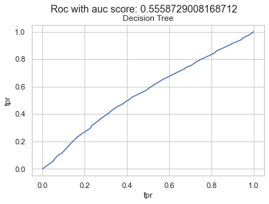

```
Classification report - Decision Tree
              precision    recall  f1-score   support

     Regular       0.39      0.60      0.47      2197
  Successful       0.70      0.49      0.58      4162

    accuracy                           0.53      6359
   macro avg       0.54      0.55      0.52      6359
weighted avg       0.59      0.53      0.54      6359
```

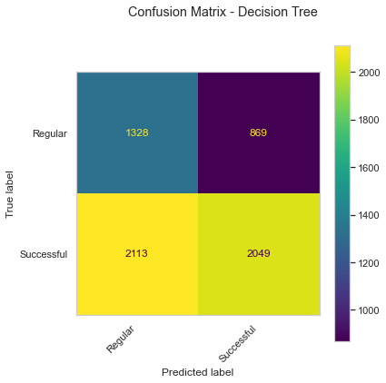

```python
model = DecisionTreeClassifier(class_weight='balanced', criterion='gini', max_depth=12, random_state=45545)
model.fit(X_train,y_train)

print('\nModel parameters - Decision Tree: ',clf.best_params_)

y_test1 = y_test.map({'Regular': 0, 'Successful': 1}).astype(int)
y_pred_prob = model.predict_proba(X_test)[:,1]
fpr, tpr, thresholds = roc_curve(y_test1, y_pred_prob)

plt.plot(fpr,tpr)
plt.xlabel('fpr')
plt.ylabel('tpr')
plt.title('Decision Tree')
plt.suptitle('Roc with auc score: {}'.format(roc_auc_score(y_test1,y_pred_prob)))
plt.show()

print('Classification report - Decision Tree')
y_pred = model.predict(X_test)
print(classification_report(y_test,y_pred, zero_division=0))

fig, ax = plt.subplots()
fig.set_size_inches(6, 6)
disp = metrics.plot_confusion_matrix(model, X_test, y_test,ax=ax)
disp.figure_.suptitle("Confusion Matrix - Decision Tree")
plt.xticks(rotation=45, ha='right')
ax.grid(False)
plt.show()
```

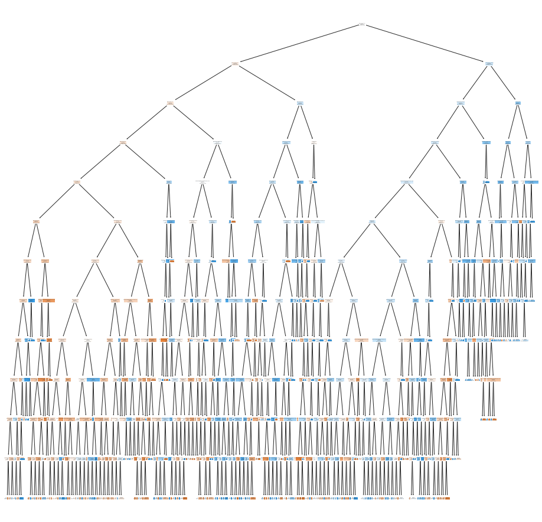

```python
fig, ax = plt.subplots()
fig.set_size_inches(16, 16)
clr = model.fit(X_test, y_test)
plot_tree(clr, filled=True,feature_names=X_test.columns,ax=ax)

plt.show()
```

We see that there is an improve in balance of classification of regular and successful classes. However, the final model is complex having many leaves.

## Fitting and validating Multilayer Perceptron:

```python
param_grid = [
        {
            'activation': ['identity', 'logistic', 'tanh', 'relu'],
            'max_iter': [100000],
            'alpha':[1e-2,1e-3,1e-4],
            'random_state': [45545],
            'tol':[1e-3,1e-4,1e-5],
            'solver': ['adam']
        }
       ]

clf = GridSearchCV(MLPClassifier(), param_grid, cv=3,
                           scoring='balanced_accuracy')
clf.fit(X,y)

print("Best parameters set found on development set:")
print(clf.best_params_)
```

```
Best parameters set found on development set:
{'activation': 'relu', 'alpha': 0.0001, 'max_iter': 100000, 'random_state': 45545, 'solver': 'adam', 'tol': 1e-05}
```

[output not shown]

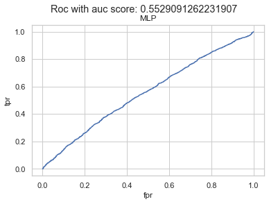

```
Classification report - MLP
              precision    recall  f1-score   support

     Regular       0.41      0.23      0.29      2197
  Successful       0.67      0.83      0.74      4162

    accuracy                           0.62      6359
   macro avg       0.54      0.53      0.52      6359
weighted avg       0.58      0.62      0.59      6359
```

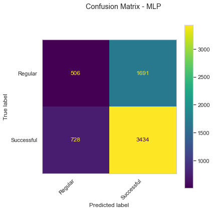

```python
model= MLPClassifier(activation= 'relu', alpha=0.0001,
                     max_iter=100000, random_state=45545, solver='adam', tol=1e-05)
model.fit(X_train_scaled,y_train)


print('\nModel parameters - MLP: ',clf.best_params_)

y_test1 = y_test.map({'Regular': 0, 'Successful': 1}).astype(int)
y_pred_prob = model.predict_proba(X_test_scaled)[:,1]
fpr, tpr, thresholds = roc_curve(y_test1, y_pred_prob)

plt.plot(fpr,tpr)
plt.xlabel('fpr')
plt.ylabel('tpr')
plt.title('MLP')
plt.suptitle('Roc with auc score: {}'.format(roc_auc_score(y_test1,y_pred_prob)))
plt.show()

print('Classification report - MLP')
y_pred = model.predict(X_test_scaled)
print(classification_report(y_test,y_pred, zero_division=0))

fig, ax = plt.subplots()
fig.set_size_inches(6, 6)
disp = metrics.plot_confusion_matrix(model, X_test_scaled, y_test,ax=ax)
disp.figure_.suptitle("Confusion Matrix - MLP")
plt.xticks(rotation=45, ha='right')
ax.grid(False)
plt.show()
```

After having analyze ROC AUC curve, classification report and confusion matrix of the models built, Logistic Regression is the chosen one for its simplicity for application and explanation.

## Fitting best model (Logistic Regression) and checking features impact

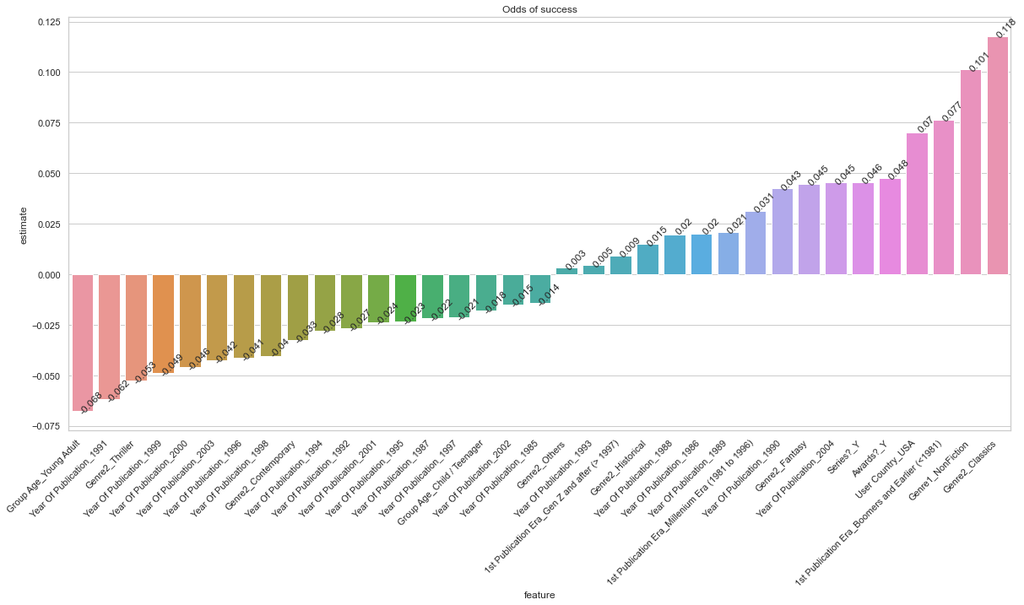

```python
model = LogisticRegression(C= 2000, class_weight='balanced',
                           max_iter=100000, random_state=45879, solver='saga', tol=1e-06)
model.fit(X_train_scaled,y_train)
# getting coefficient and feature names
coeff = pd.DataFrame([X_train_scaled.columns.ravel(),model.coef_.ravel()]).T.rename(columns={1:'estimate',0:'feature'})
coeff.sort_values(by='estimate', ascending=True,inplace=True)
fig, ax = plt.subplots()
fig.set_size_inches(20, 9)
plt.title('Odds of success')
sns.barplot(y='estimate',x='feature', data=coeff)
for p in ax.patches:
    ax.annotate(round(p.get_height(),3),
    (p.get_x()+p.get_width()/2+.3, p.get_height()),
    ha='center',va='center',xytext=(2, 10),textcoords='offset points', rotation=45)
    plt.xticks(rotation=45, ha='right')

plt.show()
```

# Conclusions

[output not shown]

# Next steps

- Consolidate publisher and feature to add to model
- Gather more data from other countries to expand User Country feature